# Landnutzungsklassifikation - Modellierung

Marvin Ludwig, Alice Ziegler

05/06/2019

# Wiederholung

## Was machen wir eigentlich?

- Einteilen eines Datensatzes in Gruppen
  - Überwacht
  - Gruppen: Landnutzungsklassen (response)
  - Datensatz: Spektrale Information (predictor)
- Klassifikationsbaum arbeitet mit Grenzen
  - Wie errechnen sich diese Grenzen?

# Wiederholung

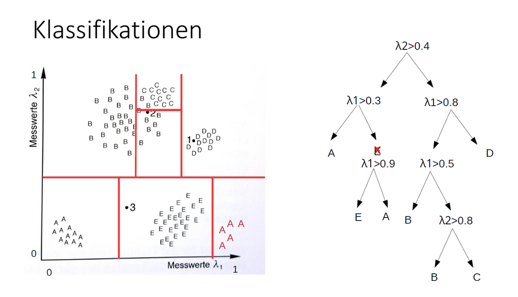

# Erstelle einen Klassifikationsbaum

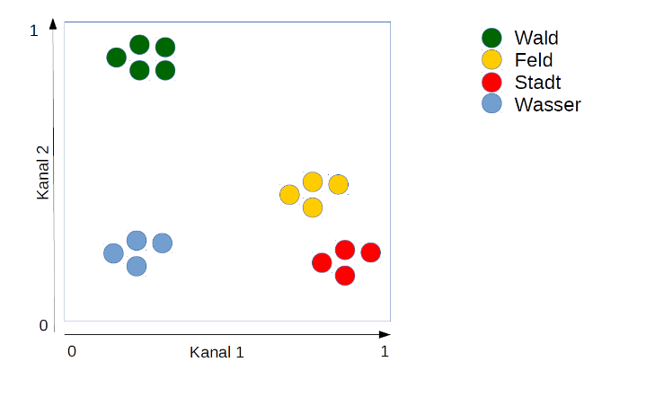

Uebung Klassifikationsbaum

# Beispiel mit dem Iris Datensatz

```r
data(iris)
iris <- iris[,c(3:5)]
head(iris)
```

```
##   Petal.Length Petal.Width Species
## 1          1.4         0.2  setosa
## 2          1.4         0.2  setosa
## 3          1.3         0.2  setosa
## 4          1.5         0.2  setosa
## 5          1.4         0.2  setosa
## 6          1.7         0.4  setosa
```

- Predictoren: Petal.Length, Petal.Width
- Response: Species

# Beispiel mit dem Iris Datensatz

```r
# install.packages("tree")
library(tree)

kb <- tree(Species ~ .,
           data = iris,
           split = "deviance")
summary(kb)
```

```
##
## Classification tree:
## tree(formula = Species ~ ., data = iris, split = "deviance")
## Number of terminal nodes:  5
## Residual mean deviance:  0.157 = 22.77 / 145
## Misclassification error rate: 0.02667 = 4 / 150
```

# Beispiel mit dem Iris Datensatz

[figure not shown]

# Beispiel mit dem Iris Datensatz

[figure not shown]

# Wie werden die Grenzen berechnet?

- Maschinelles Lernen
  - Lernt “selbstständig” Zusammenhänge in den Daten
  - Benutzt dafür Fehlermaße um optimale Modelle zu finden
  - Dafür wird der Datensatz aufgeteilt um zu testen, wie gut die Einteilung der Gruppen funktioniert

# Nochmal mit dem Ganzen Iris Datensatz

```r
data(iris)
head(iris)
```

```
##   Sepal.Length Sepal.Width Petal.Length Petal.Width Species
## 1          5.1         3.5          1.4         0.2  setosa
## 2          4.9         3.0          1.4         0.2  setosa
## 3          4.7         3.2          1.3         0.2  setosa
## 4          4.6         3.1          1.5         0.2  setosa
## 5          5.0         3.6          1.4         0.2  setosa
## 6          5.4         3.9          1.7         0.4  setosa
```

```r
kb <- tree(Species ~ .,
           data = iris,
           split = "deviance")
```

# Nochmal mit dem ganzen Iris Datensatz

```r
plot(kb); text(kb)
```

[figure not shown]

# Nochmal mit dem ganzen Iris Datensatz

[figure not shown]

# Random Forest

- 2001 von Leo Breiman
- Klassifikationsbaum ist die Grundlage

# Random Forest

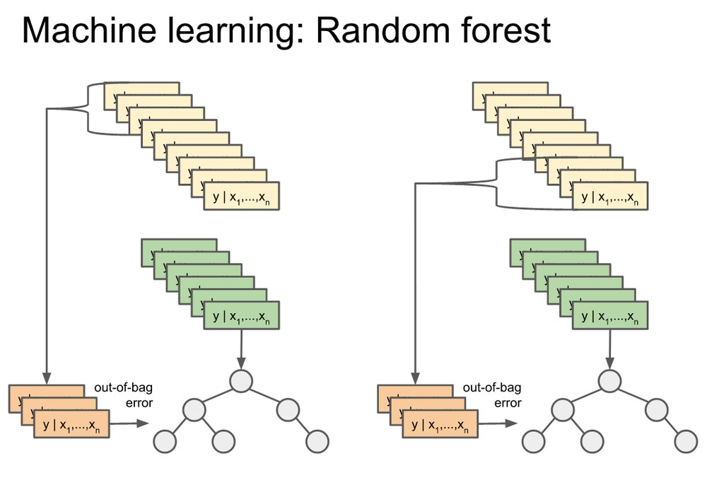

# Was ist random an Random Forest?

- Bootstrap Sample fuer jeden Baum
  - “Ziehen mit zurücklegen”
  - Für jeden Klassifikationsbaum wird also eine andere Datengrundlage verwendet
- Praediktorenauswahl in jedem Baum
  - Anzahl der betrachteten Praediktoren wird festgelegt (mtry)
  - mtry ist der sogenannte “tuning parameter” für Random Forest
  - Ein Ziel des maschinellen Lernens ist es diesen parameter optimal zu bestimmen

# Random Forest in R

- Installieren Sie die Pakete caret und ranger

# Random Forest in R

- Laden Sie die .RDS Datei von letzter Woche ein
- Splitten Sie den Datensatz in einen Training- und Testdatensatz
  - Training soll zufällig 70% der Daten beinhalten
  - Test dementsprechend die übrigen 30%
  - ?set.seed()
  - ?createDataPartition()

# Random Forest in R

- Trainieren sie ein Random Forest Model
  - Nutzen Sie dafür den Trainingsdatensatz
  - caret::train()
  - Speichern Sie das Modell als RDS-Datei ab

# Random Forest in R

- Wenden Sie das Modell auf das gesamte Untersuchungsgebiet an
  - ?raster::predict()
- Schauen Sie sich das Ergebnis an
  - ?spplot()